# Data Question 4

Skirmish Guards (Vinay, Shruti, & James)

February 3rd, 2018

### Where did the data come from?

- Academic, demographic, and disciplinary education data gathered from [the 2014 - 2015 TN.gov](https://www.tn.gov/education/data/data-downloads.html).
- Organized zipcodes by county [Zip Codes](https://www.unitedstateszipcodes.org/zip-code-database/).
- Aggregated tax infomration organized by zipcode [2011 - 2015 IRS Data](https://www.irs.gov/statistics/soi-tax-stats-individual-income-tax-statistics-zip-code-data-soi).

### Brief History of Public Education in TN

- The state’s fisrt constitution (1796) did not mention education as an appropriation of public funds.
- The offical recognition of public education came in 1806 within the federal Cession Act, requiring the state to furnish land for two colleges and an academy in each of the 27 existing counties within the state at the time.
- State general assembly statues throughout 1815-1830’s proved to be ineffective due to lack of funding. County boards were independent and uncompensated.
- 1835 state constitution included a education provision, installing a superintendent.
- 1867 Reconstruction intiatives revive resources to be dedicated to education.
- General Education ACt of 1909 - 25% of state gross revenue to be utilized by the counties for public schools.
- 1954 Brown vs Board of Education and resulting desegregation in the years to come.
- 2002 Tennessee Education Lottery ($10.8 million in sales on the first day)
- Common Core Initiative was adopted in 2010 and implemented in 2013.

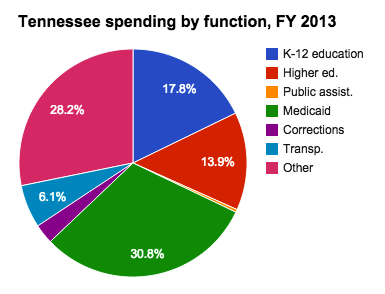

TN State Expenditure by Type 2013

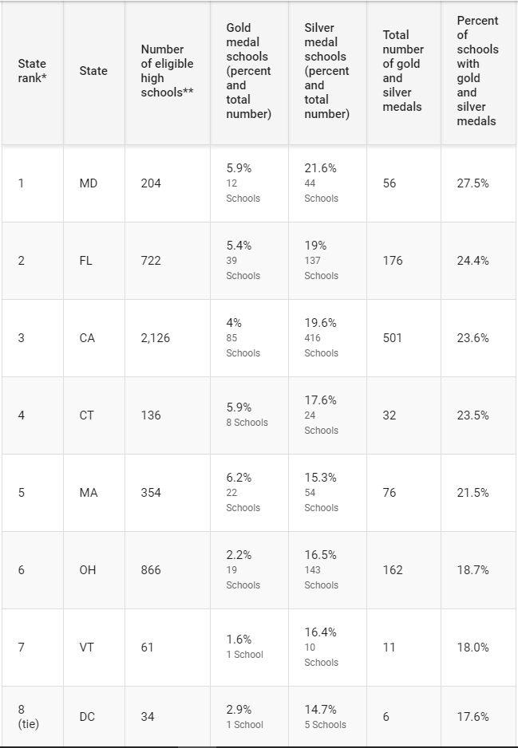

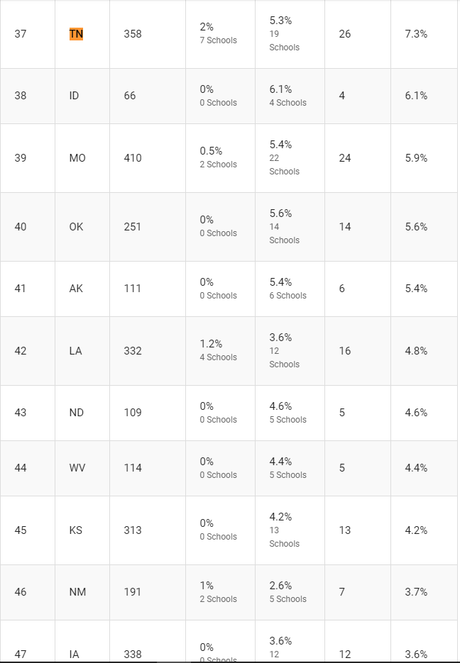

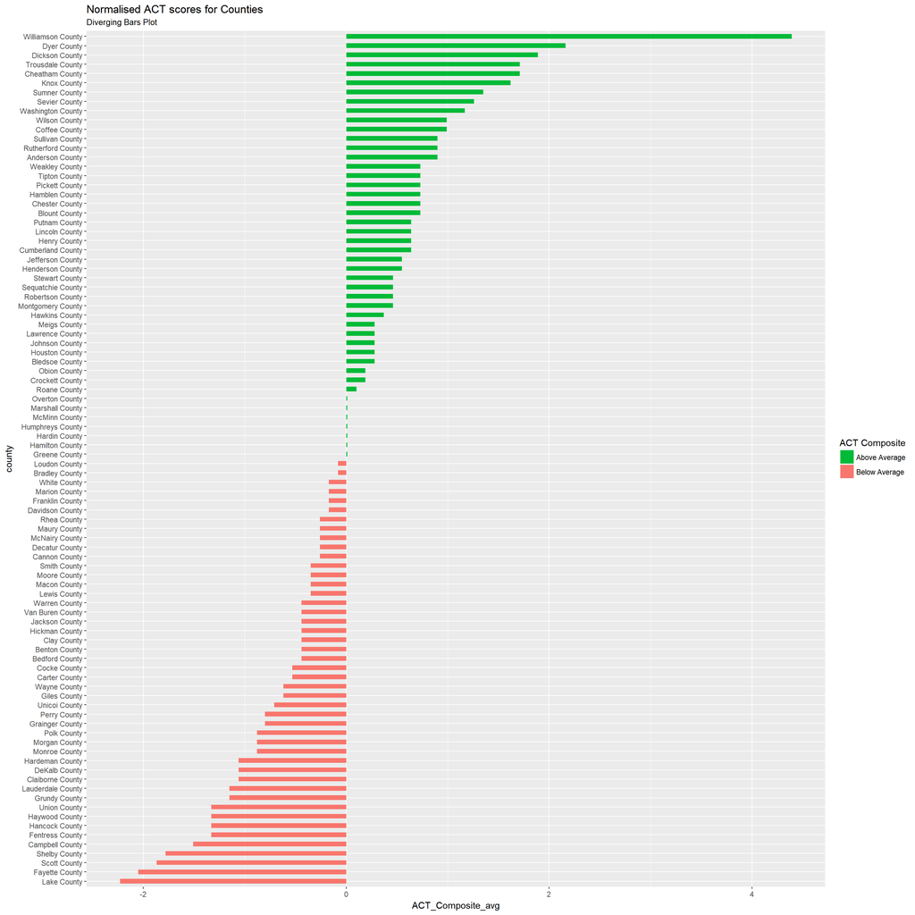

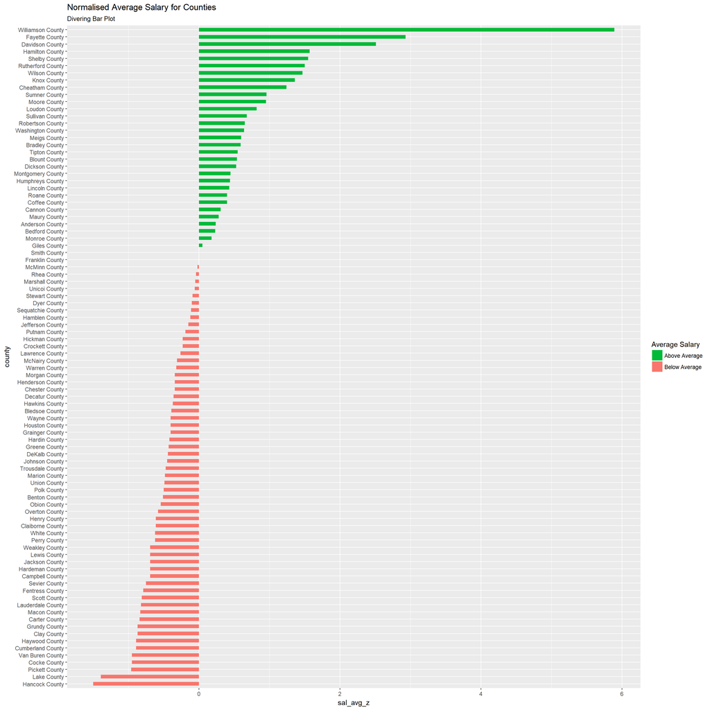

### Correlation Matrix of Averaged IRS Data

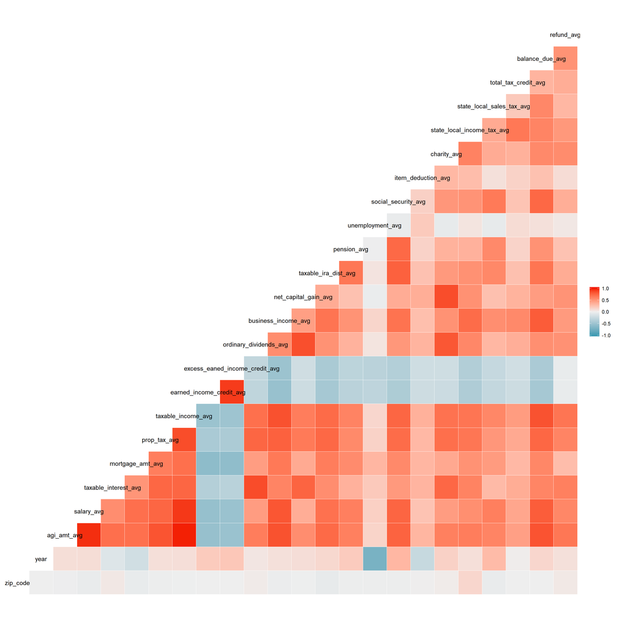

### Correlation Matrix of CORE Education Data

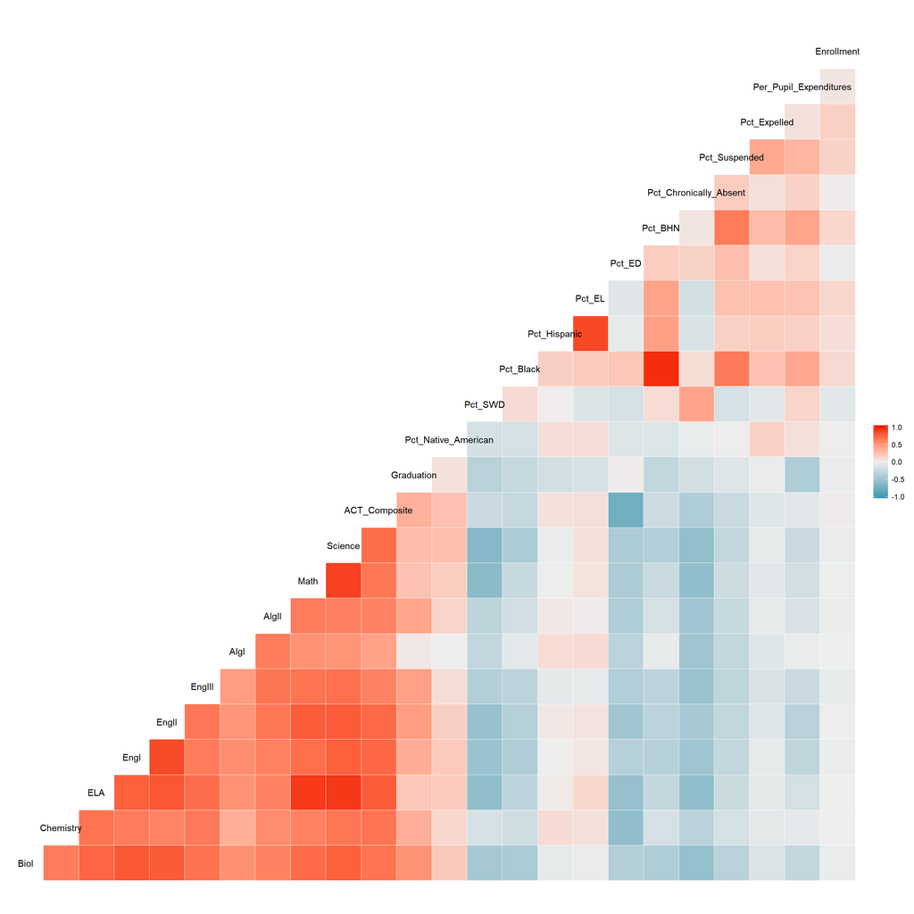

### Per Pupil Expenditure

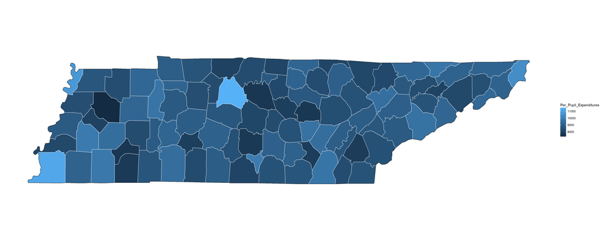

### Percentage of Black, Hispanic, and Native American

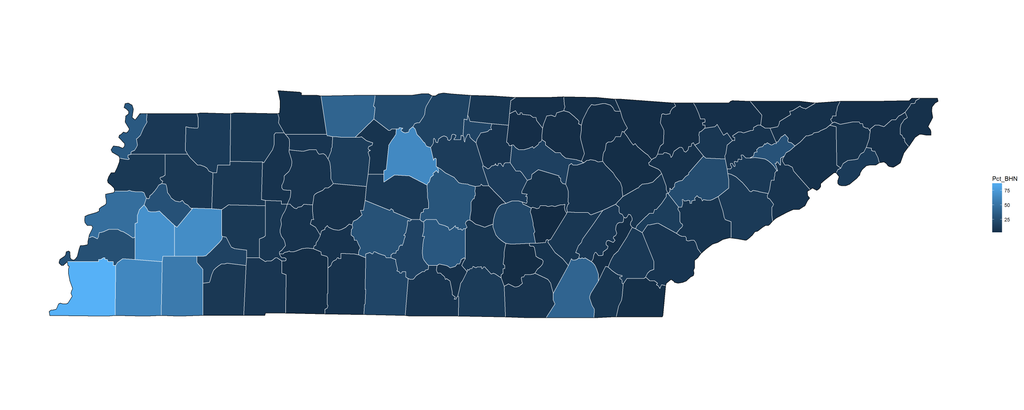

### Graduation Rate

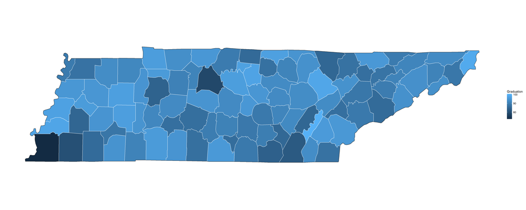

### Dropout Rate

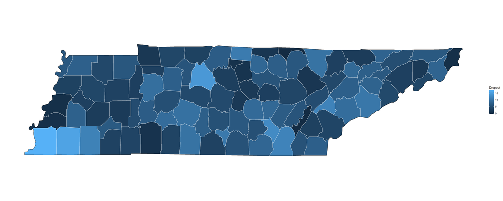

### Model Prediction of Core Scores Effect on ACT Score

```r
lm(formula = ACT_Composite ~  avg_Eng + avg_Math + avg_Sci + Dropout + Pct_Suspended,  data = merged_irs)
```

```
##
## Call:
## lm(formula = ACT_Composite ~ avg_Eng + avg_Math + avg_Sci + Dropout +
##     Pct_Suspended, data = merged_irs)
##
## Coefficients:
##   (Intercept)        avg_Eng       avg_Math        avg_Sci        Dropout
##     11.114965       0.104072       0.010566       0.020567       0.039315
## Pct_Suspended
##      0.003943
```

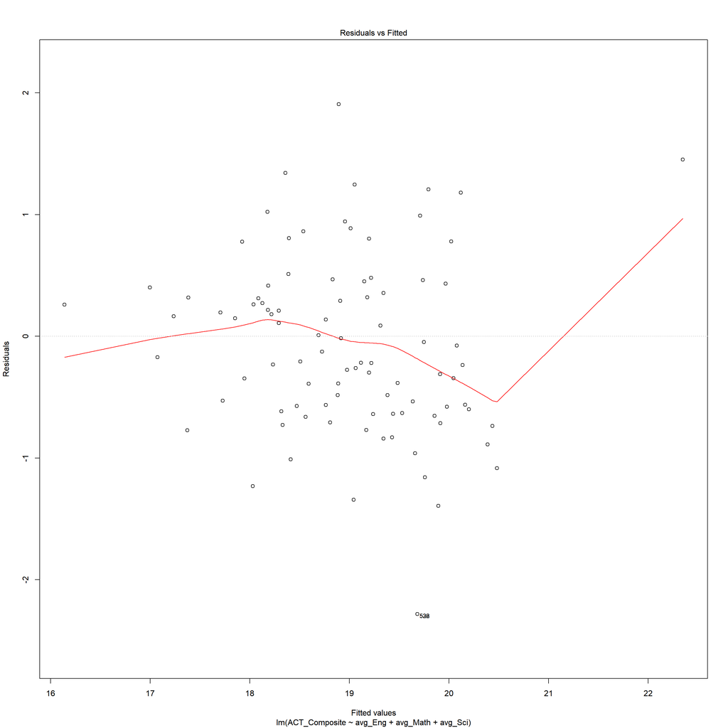

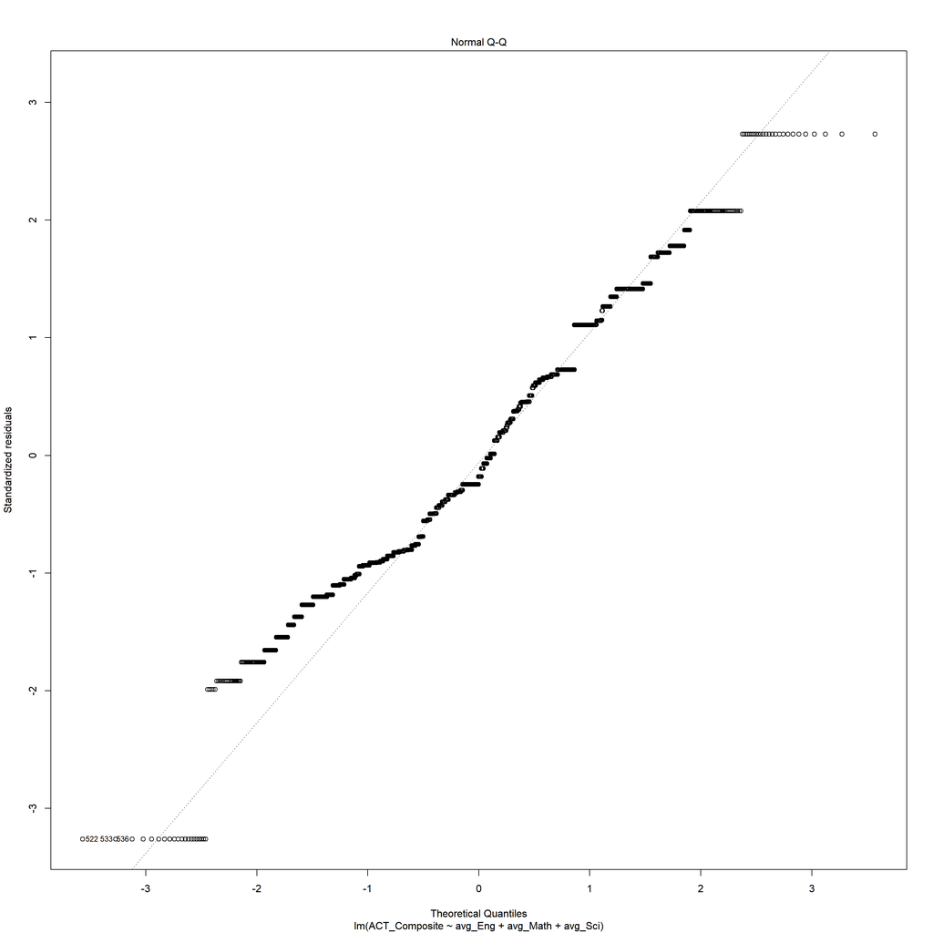

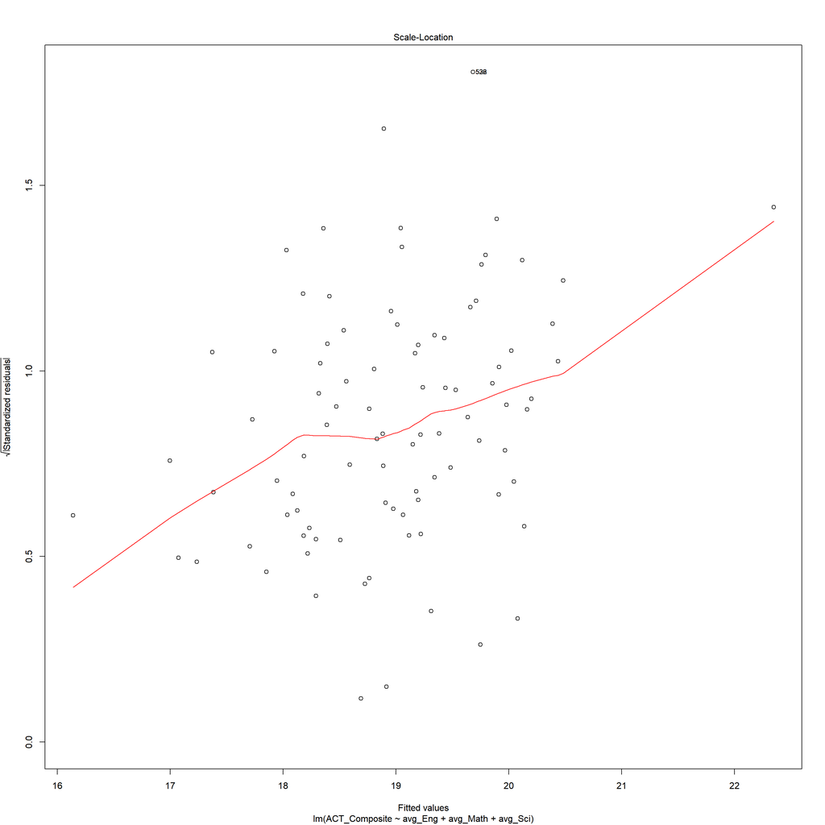

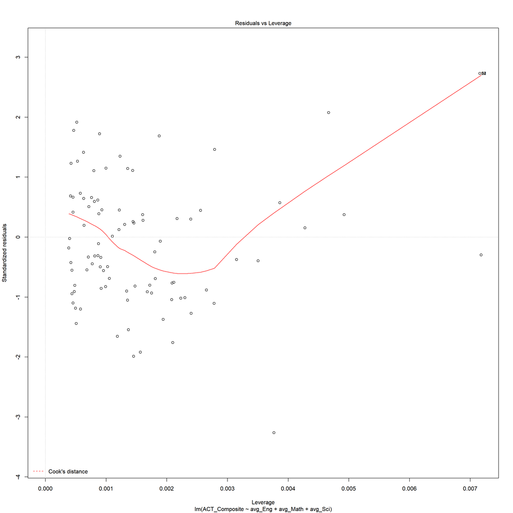

```r
          model_multi <- lm(formula = ACT_Composite ~  avg_Eng + avg_Math + avg_Sci, data = merged_irs)
          plot(model_multi)
```

```r
          summary(model_multi)
```

```
##
## Call:
## lm(formula = ACT_Composite ~ avg_Eng + avg_Math + avg_Sci, data = merged_irs)
##
## Residuals:
##     Min      1Q  Median      3Q     Max
## -2.2815 -0.5650 -0.1270  0.4809  1.9070
##
## Coefficients:
##              Estimate Std. Error t value Pr(>|t|)
## (Intercept) 12.114030   0.099123 122.212  < 2e-16 ***
## avg_Eng      0.095159   0.004602  20.676  < 2e-16 ***
## avg_Math     0.010742   0.001736   6.190 6.91e-10 ***
## avg_Sci      0.016612   0.003327   4.994 6.29e-07 ***
## ---
## Signif. codes:  0 '***' 0.001 '**' 0.01 '*' 0.05 '.' 0.1 ' ' 1
##
## Residual standard error: 0.7008 on 2801 degrees of freedom
## Multiple R-squared:  0.6806, Adjusted R-squared:  0.6803
## F-statistic:  1990 on 3 and 2801 DF,  p-value: < 2.2e-16
```

```r
          # use model to predict the results
          test_model <- data.frame(avg_Eng = 80, avg_Math = 80,  avg_Sci = 80)
          test_model2 <- data.frame(avg_Eng = 90, avg_Math = 90,  avg_Sci = 90)
          test_model3 <- data.frame(avg_Eng = 60, avg_Math = 50,  avg_Sci = 60)
          #test_counts <- model_multi$agi_amt_avg

          predict(model_multi, test_model)
```

```
##        1
## 21.91506
```

```r
          predict(model_multi, test_model2)
```

```
##        1
## 23.14019
```

```r
          predict(model_multi, test_model3)
```

```
##        1
## 19.35738
```

$$ACT_Composite = 12.114030 + 0.095159 * avg_Eng + 0.010742 * avg_Math + 0.016612 * avg_Sci$$